# Introduction

Jonathan Kennel, Beth Parker

2025-01-27

## Code background

**earthtide** is a port of the ‘Fortran ETERNA 3.4’ (Wenzel, 1996) predict and part of the analyze codes with the Kudryavtsev 2004 update. The original ‘Fortran’ code was rewritten in **R**, and **C++** using **Rcpp**, **RcppEigen**, and **RcppThread**. The package is useful for generating synthetic earth tides using highly accurate tidal catalogs for prediction and regression. Attempts were made to ensure that results were consistent with the ‘ETERNA 3.4’, however, there is always the possibility that a bug was introduced during the conversion and update.

## Capabilities

The following tidal componenents are implemented in **earthtide**.

| Tidal component | Status | Output units |
| --- | --- | --- |
| tidal_potential | tested | $meters^2/second^2$ |
| gravity | tested | $nanometers/second^2$ |
| tidal_tilt | tested | $milliarcsec$ |
| vertical_displacement | tested | $millimeter$ |
| horizontal_displacement | preliminary | $millimeter$ |
| n_s_displacement | preliminary | $millimeter$ |
| e_w_displacement | preliminary | $millimeter$ |
| vertical_strain | tested | $nanostrain$ |
| areal_strain | tested | $nanostrain$ |
| volume_strain | tested | $nanostrain$ |
| horizontal_strain | tested | $nanostrain$ |
| ocean_tides | preliminary | $millimeter$ |

## Example

The primary inputs are the date-time in UTC, the component name from the previous table, and the latitude and longitude. For most cases these are the minimum requirements necessary. For the full list of options see the documentation for *calc_earthtide*.

```r
tms <- as.POSIXct("2015-01-01", tz = "UTC") + 0:(24*31) * 3600

gravity_tide <- calc_earthtide(utc = tms,
                               method = 'gravity',
                               latitude = 52.3868,
                               longitude = 9.7144)
```

There are two main methods of generating Earth tides: predict and analyze. Predict returns the combined tidal signal, and analyze returns a set of sin and cos curves for each wave group that is specified. This option is set using the **do_predict** parameter which defaults to TRUE.

### Predict

```r
gravity_tide <- calc_earthtide(utc = tms,
                               do_predict = TRUE,
                               method = 'gravity',
                               latitude = 52.3868,
                               longitude = 9.7144)
```

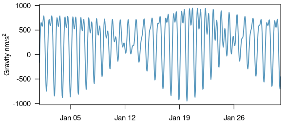

### Analyze

In analyze mode, results are separated by wave group into sin and cos curves. The resulting sin and cos curves can be used in further analysis such as least squares models. The first five constituents are plotted in the following example. The **wave_groups** parameter is specified using a *data.frame* having the start and end frequencies for each component.

```r
wg <- eterna_wavegroups
wg <- na.omit(wg[wg$time=='1 month',])

tides <- calc_earthtide(utc = tms,
                        do_predict = FALSE,
                        method = 'gravity',
                        latitude = 52.3868,
                        longitude = 9.7144,
                        wave_groups = wg)
```

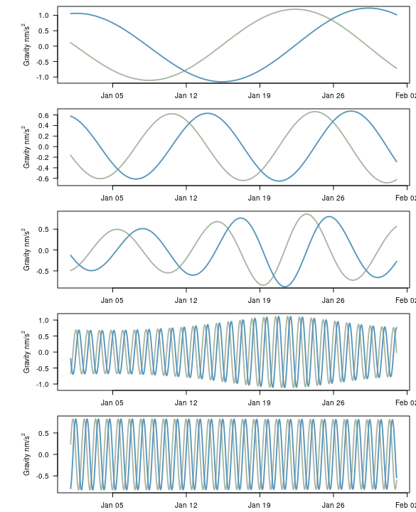

## Wave grouping

The choice of wave groups is important. Wave groups are specified using a *data.frame* of start and end values for each group. Example groupings are provided in the dataset **eterna_wavegroups**. The choice of the appropriate wave groups is dependent purpose of the study and the duration of the dataset to be analyzed. For example, if the goal is to generate tidal harmonics to analyze one (1) month of data you would select the “1 month” dataset.

```r
tms <- as.POSIXct("2015-01-01", tz = "UTC") + 0:(24*31) * 3600

wg <- eterna_wavegroups
wg <- na.omit(wg[wg$time=='1 month',])

head(wg)
```

```
##   name    start      end    time
## 3   MM 0.020885 0.054747 1 month
## 4   MF 0.054748 0.091348 1 month
## 5  MTM 0.091349 0.501369 1 month
## 6   Q1 0.501370 0.911390 1 month
## 7   O1 0.911391 0.947991 1 month
## 8   M1 0.947992 0.981854 1 month
```

## LOD (length of day) tide and pole tide

The Length of Day (LOD) and Pole tides can also be calculated. These results differ from ETERNA in that we interpolate using splines.

```r
tide <- calc_earthtide(utc = tms,
                       method = c('lod_tide', 'pole_tide'),
                       latitude = 52.3868,
                       longitude = 9.7144)
```

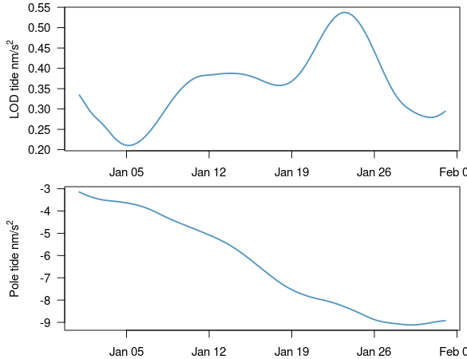

## Speed for large datasets

Speeding up the generation of tidal datasets can be achieved in a few ways: - reduce the number of waves used. The **cutoff** parameter controls how many waves are used. A larger cutoff value means fewer waves will be used leading to a faster but less accurate result. - use a higher number for astro_update. This introduces an approximation for when astronomical parameters are updated and can provide significant speed-ups. By default a value of 1 is used. - interpolate values using the *utc_interp* parameter to *calc_earthtide*. For example you can generate you series every 60 seconds and interpolate to 1 second. - use more threads. This can be done by setting *n_thread* argument to *calc_earthtide* - a combination of above

In general, the speed should be as good as or better than the fortran version of ETERNA if similar parameters are used.

## References

Hartmann, T., Wenzel, H.-G., 1995. The HW95 tidal potential catalogue. Geophys. Res. Lett. 22, 3553–3556. \url(https://doi.org/10.1029/95GL03324)

Kudryavtsev, S.M., 2004. Improved harmonic development of the Earth tide-generating potential. J. Geod. 77, 829–838. \url(https://doi.org/10.1007/s00190-003-0361-2)

Wenzel, H.G. 1996: The nanogal software: Earth tide data processing package ETERNA 3.30. Bull. Inf. Marges Terrestres. 124, 9425-9439.

## TODO:

This package is still in development. The following changes are planned:

- Speed enhancements
- Print methods and getter/setters for love numbers, catalog, station variables
- Optional wave group names
- Ocean loading
- Updated examples
- Calculations on a grid
- Other earth models